## Libraries and loading data

```r
library(tidyverse)
library(stringr)
df = read.csv("https://raw.githubusercontent.com/wagstrom/ds-202-final-project/main/rym_top_5000_all_time.csv")
```

In this chunk we read in our data from our working repository.

## Converting to numeric

```r
df$Number.of.Ratings = as.numeric(gsub(",", "", df$Number.of.Ratings))
df$Ranking = as.numeric(df$Ranking)
df$Average.Rating = as.numeric(df$Average.Rating)
df$Number.of.Reviews = as.numeric(df$Number.of.Reviews)
df2 = df
```

In this chunk we set our ratings, number of ratings, rankings, and number of reviews as numerical values instead of string values.

## Converting comma-separated strings into separate columns

```r
df2[c('Genre_1', 'Genre_2', 'Genre_3', 'Genre_4', 'Genre_5')] <- str_split_fixed(df2$Genres, ', ', 5)
df2[c('Desc_1', 'Desc_2', 'Desc_3', 'Desc_4', 'Desc_5', 'Desc_6', 'Desc_7', 'Desc_8',
     'Desc_9', 'Desc_10')] <- str_split_fixed(df2$Descriptors, ', ', 10)
sum(df2$Desc_10 != "")
```

```
## [1] 3344
```

```r
df3 = df2
```

In this chunk we are splitting our genres and descriptors into different columns that makes the album values less unique.

## Add column for average score, average reviews, average ratings, and number of appearances per artist

```r
library(lubridate)
df3 = df3 %>%
  group_by(Artist.Name) %>%
  mutate(Artist.Average.Score = mean(Average.Rating),
         Artist.Average.Reviews = mean(Number.of.Reviews),
         Artist.Average.Ratings = mean(Number.of.Ratings),
         Artist.Frequency = nrow(as.data.frame(Artist.Name))
         )

df_final = df3
```

Dealing with Dates

```r
Year_useful = str_sub(df_final$Release.Date,-2,-1)

library(lubridate)
Year_start = NULL
for(i in 1:5000){
  if(Year_useful[i] <  22){
    Year_start[i] = 20
    }else{
    Year_start[i] = 19
  }
}

year = data.frame(Year_start, Year_useful)

df_final$Year = paste(year$Year_start, year$Year_useful)
df_final$Year = gsub(" ", "", df_final$Year)

Month = gsub("[^a-zA-Z]", "",df_final$Release.Date )
df_final$Month = Month

Day = parse_number(str_sub(df_final$Release.Date,,2))
df_final$Day=factor(Day)
```

In this chunk we are adding columns to find the averages of scores, reviews, number of ratings, and number of appearances for each artist. We do this so we can compare the individual values easier.

## Summaries

```r
nrow(unique(as.data.frame(df_final$Album)))
```

```
## [1] 4928
```

```r
  #Some albums have the same names
nrow(unique(as.data.frame(df_final$Artist.Name)))
```

```
## [1] 2787
```

```r
  #2787 unique artists
nrow(unique(as.data.frame(df_final$Genre_1)))
```

```
## [1] 453
```

```r
  #453 unique primary genres
summary(df_final)
```

```
##     Ranking        Album           Artist.Name        Release.Date
##  Min.   :   1   Length:5000        Length:5000        Length:5000
##  1st Qu.:1251   Class :character   Class :character   Class :character
##  Median :2500   Mode  :character   Mode  :character   Mode  :character
##  Mean   :2500
##  3rd Qu.:3750
##  Max.   :5000
##
##     Genres          Descriptors        Average.Rating  Number.of.Ratings
##  Length:5000        Length:5000        Min.   :3.520   Min.   :  260.0
##  Class :character   Class :character   1st Qu.:3.700   1st Qu.:  752.8
##  Mode  :character   Mode  :character   Median :3.750   Median : 1820.0
##                                        Mean   :3.771   Mean   : 4084.5
##                                        3rd Qu.:3.810   3rd Qu.: 4719.2
##                                        Max.   :4.340   Max.   :70382.0
##
##  Number.of.Reviews   Genre_1            Genre_2            Genre_3
##  Min.   :   0.00   Length:5000        Length:5000        Length:5000
##  1st Qu.:  14.00   Class :character   Class :character   Class :character
##  Median :  34.00   Mode  :character   Mode  :character   Mode  :character
##  Mean   :  71.45
##  3rd Qu.:  82.25
##  Max.   :1549.00
##
##    Genre_4            Genre_5             Desc_1             Desc_2
##  Length:5000        Length:5000        Length:5000        Length:5000
##  Class :character   Class :character   Class :character   Class :character
##  Mode  :character   Mode  :character   Mode  :character   Mode  :character
##
##
##
##
##     Desc_3             Desc_4             Desc_5             Desc_6
##  Length:5000        Length:5000        Length:5000        Length:5000
##  Class :character   Class :character   Class :character   Class :character
##  Mode  :character   Mode  :character   Mode  :character   Mode  :character
##
##
##
##
```

[output cut: 9 more lines]

```
##  Min.   :3.520        Min.   :  0.00         Min.   :  260
##  1st Qu.:3.713        1st Qu.: 16.00         1st Qu.:  851
##  Median :3.757        Median : 37.00         Median : 1931
##  Mean   :3.771        Mean   : 71.45         Mean   : 4085
##  3rd Qu.:3.812        3rd Qu.: 84.25         3rd Qu.: 4973
##  Max.   :4.340        Max.   :929.00         Max.   :46438
##
##  Artist.Frequency     Year              Month                Day
##  Min.   : 1.000   Length:5000        Length:5000        19     : 884
##  1st Qu.: 1.000   Class :character   Class :character   20     : 148
##  Median : 2.000   Mode  :character   Mode  :character   25     : 139
##  Mean   : 3.025                                         1      : 138
##  3rd Qu.: 4.000                                         22     : 124
##  Max.   :25.000                                         (Other):2461
##                                                         NA's   :1106
```

In this chunk we are exploring the data to see how many unique albums, artists, and genres in the data. We also ran a summary of the dataframe so we could view it easier.

Our project idea is as follows:

Our dataset is the list of the top 5000 rated albums on the website rateyourmusic.com. The dataset includes the ranking, album title, artist, release date, genre(s), descriptors, average rating, number of ratings, number of reviews. We have several questions we’d like to answer through statistical analysis and visualization, some of which are listed below:

-What is the relationship between the release date and the score of the album?

-What is the relationship between the number of reviews/ratings and the artist? This helps determine the relative popularity of artists on this website.

-What is the relationship between score and other variables, such as genre, descriptors, and artist?

-How do scores for genres change over time?

**Outline of Exploration:**

-What is the relationship between the release date and the score of the album? **Quita**

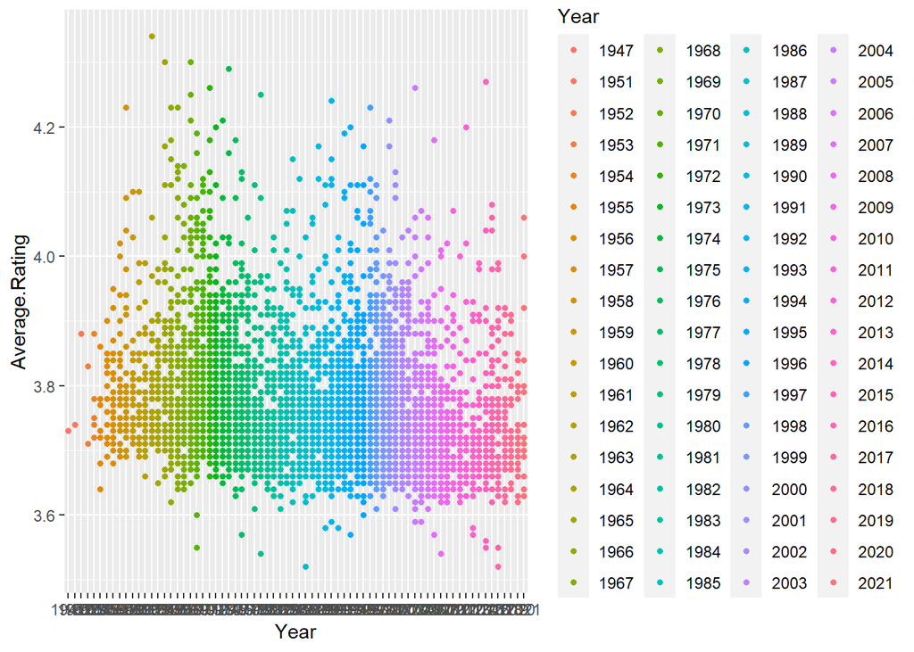

```r
library(ggplot2)
ggplot(df_final, aes(x=`Year` , y =`Average.Rating`, color= `Year` ))  + geom_point(size=1.25)
```

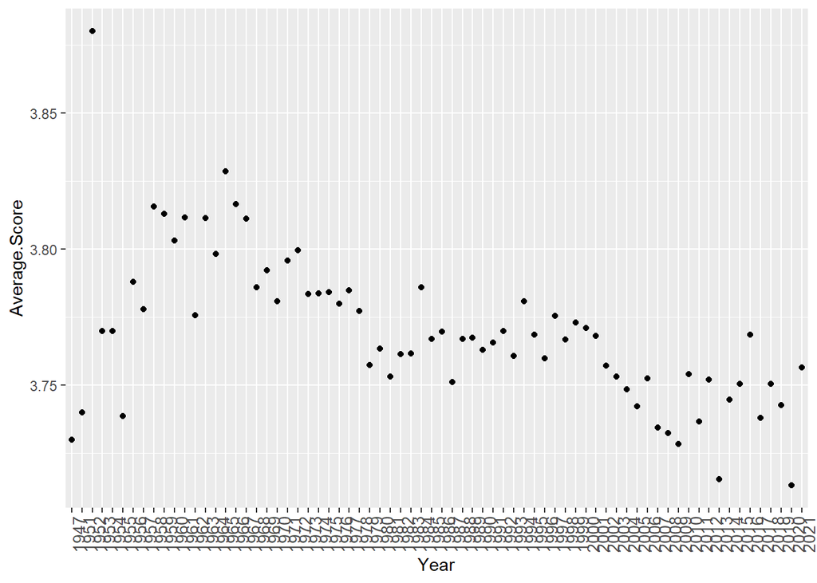

```r
df_final%>%group_by(Year)%>% summarise(
  Average.Score =mean(Average.Rating)
)%>% ggplot(aes(x=Year,y=Average.Score))+geom_point()+ theme(axis.text.x = element_text(angle = 90, size = 10))
```

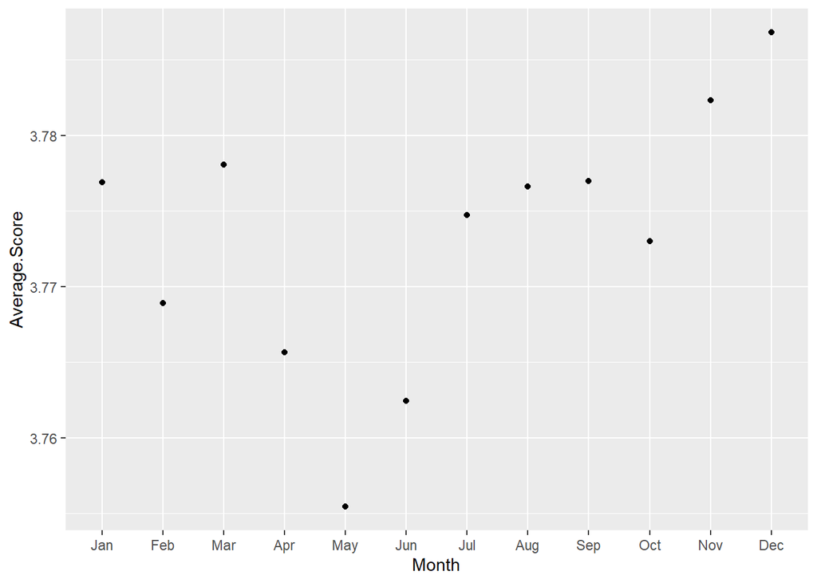

```r
df_final%>% filter(
  !(Month=="")) %>%group_by(Month)%>%summarise(
  Average.Score = mean(Average.Rating),
  Year = Year
  )%>%  mutate(Month = factor(Month, levels=c("Jan","Feb","Mar","Apr","May","Jun","Jul","Aug","Sep", "Oct","Nov","Dec")))%>%ggplot(aes(x=Month,y=Average.Score))+geom_point()
```

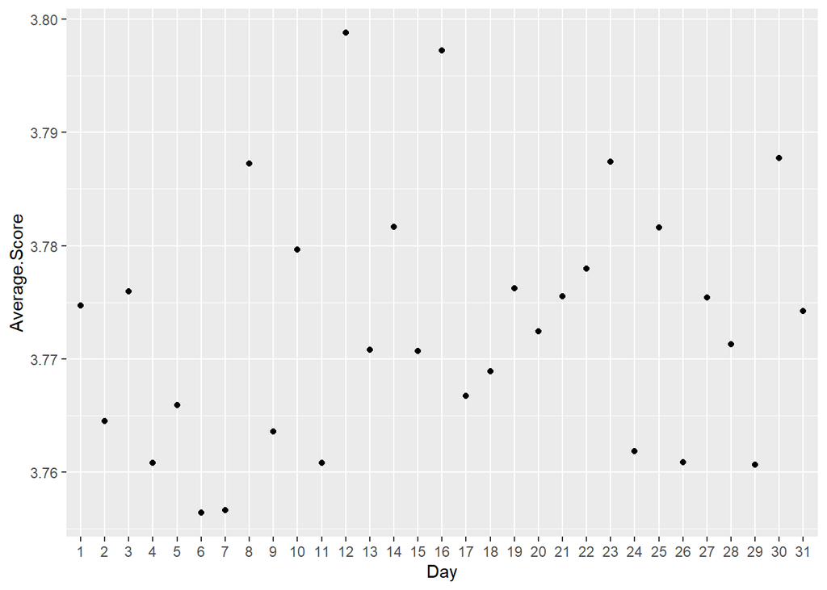

```r
df_final%>% filter(
  !(Month==""),!(Day==""))%>% group_by(Day)%>%summarise(
  Average.Score = mean(Average.Rating)
  )%>%ggplot(aes(x=Day,y=Average.Score))+geom_point()
```

[output not shown]

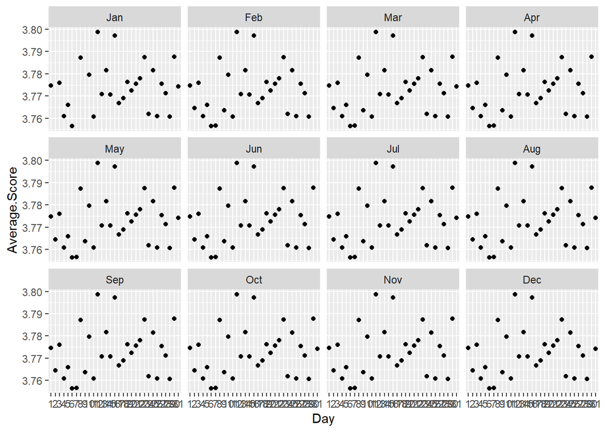

```r
df_final%>% filter(
  !(Month==""),!(Day==""))%>% group_by(Day)%>%summarise(
  Average.Score = mean(Average.Rating),
  Month = Month
  )%>%  mutate(Month = factor(Month, levels=c("Jan","Feb","Mar","Apr","May","Jun","Jul","Aug","Sep", "Oct","Nov","Dec")))%>%ggplot(aes(x=Day,y=Average.Score))+geom_point()+facet_wrap(~Month)
```

- What are the genres that dominated each decade?

-Artist that dominated the genres?

-What is the relationship between the number of reviews/ratings and the artist? This helps determine the relative popularity of artists on this website.

**Soren** # Question 2: Who are the most well-known artists on this website, and does that correlate with high scores?

Answering this question will involve determining the average number of ratings/reviews per artist. This can be accomplished using mutate statements to create two new columns, one for average number of ratings per artist, and one for average number of reviews per artist. The number of reviews per artist will be much lower than the number of ratings, because writing a review takes much more time and effort than simply providing a score from 1-5. This is not a reflection of an artist’s popularity outside the context of this website, as this is a website for dedicated fans of music, who tend to have different tastes than the general public.

The average number of ratings and reviews per artist from each of their appearances on this list is already determined by the data processing above, so the only step remaining for this question is to visualize and communicate the results.

The plot below shows the top 10 artists by average number of ratings. Radiohead tops the list, followed by The Velvet Underground and Nirvana. These are all very popular mainstream artists, so there is no surprise here. They all have very high average scores as well, indicating that these artists are as beloved as they are famous. There are some less well-known artists on this list as well, such as Slint and Godspeed You, Black Emperor!, which may indicate that these artists are more popular among music enthusiast crowds like the RateYourMusic community than among the general public.

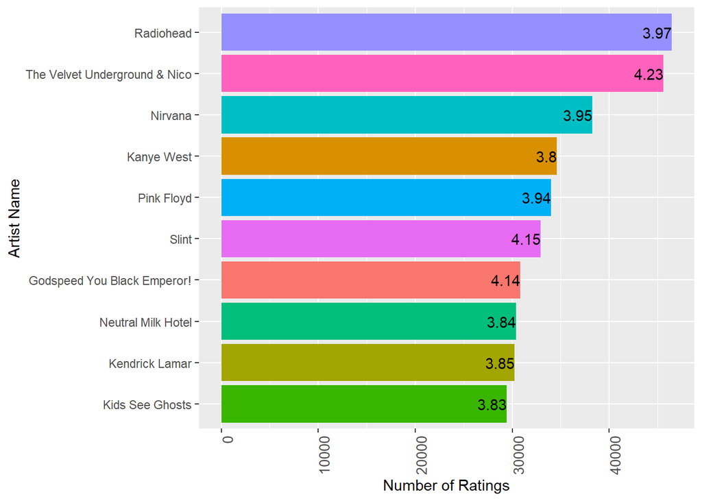

```r
# Artist popularity by ratings
df_sorted_ratings = df_final[order(-df_final$Artist.Average.Ratings),]
df_sorted_ratings = df_sorted_ratings[,c(3, 25, 27)]
df_sorted_ratings = unique(df_sorted_ratings)[1:10,]
df_sorted_ratings %>%
  ggplot(aes(x = reorder(Artist.Name, Artist.Average.Ratings),
             y = Artist.Average.Ratings, fill = Artist.Name)) +
  geom_bar(stat="identity") + coord_flip() +
  theme(axis.text.x = element_text(angle = 90, size = 10, hjust = 1)) +
  theme(legend.position="none") +
  labs(x = "Artist Name", y = "Number of Ratings") +
  geom_text(aes(label=round(Artist.Average.Score, digit = 2), hjust = 1))
```

The next plot, shown below, includes the top 10 artists by average number of reviews. Again, The Velvet Underground and Nirvana are in the top 3, but Pink Floyd takes the third spot this time around, followed closely by Radiohead.

There are two outliers in the top 10 in terms of score here. Both Guns N’ Roses and The Sex Pistols have a much lower average score than the others on this list. One conclusion that could be drawn from this statistic it that while these two artists are clearly very well known, they are not as widely beloved among music enthusiasts as others on this list, and their fame may somewhat overrate the quality of their music.

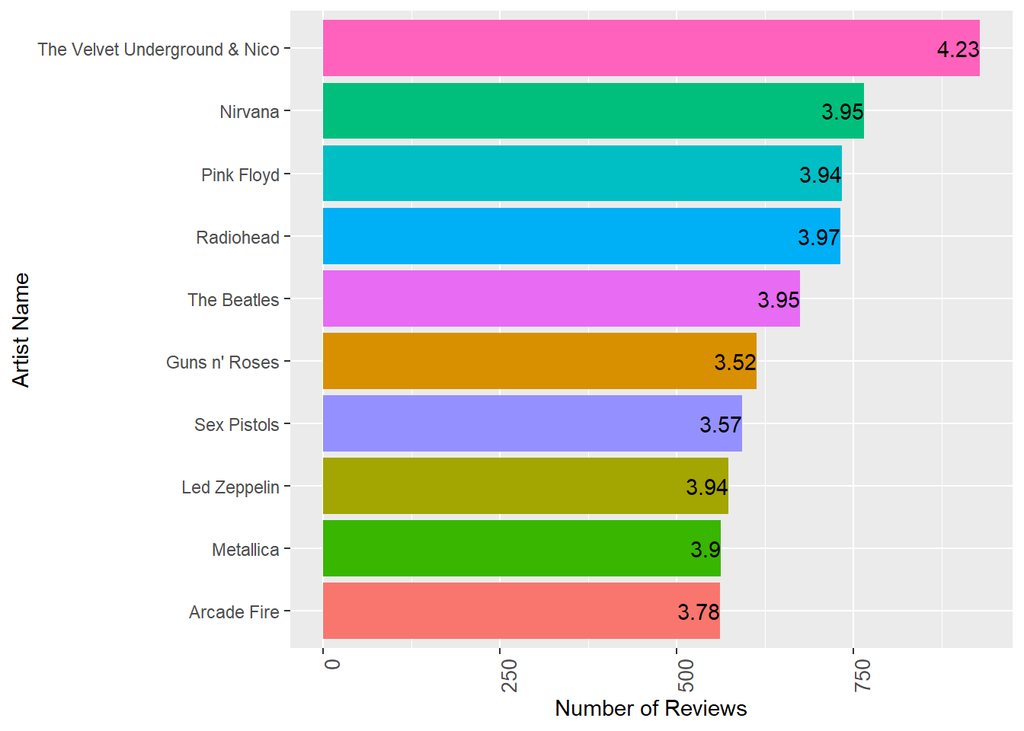

```r
# Artist popularity by reviews
df_sorted_reviews = df_final[order(-df_final$Artist.Average.Reviews),]
df_sorted_reviews = df_sorted_reviews[,c(3, 25, 26)]
df_sorted_reviews = unique(df_sorted_reviews)[1:10,]
df_sorted_reviews %>%
  ggplot(aes(x = reorder(Artist.Name, Artist.Average.Reviews),
             y = Artist.Average.Reviews, fill = Artist.Name)) +
  geom_bar(stat="identity") + coord_flip() +
  theme(axis.text.x = element_text(angle = 90, size = 10, hjust = 1)) +
  theme(legend.position="none") +
  labs(x = "Artist Name", y = "Number of Reviews") +
  geom_text(aes(label=round(Artist.Average.Score, digit = 2), hjust = 1))
```

________________________________________________________________________________________________________________

# Question: How do scores for genres change over time?

```r
length(unique(df_final$Genre_1))
```

```
## [1] 453
```

```r
df_final %>% group_by(Genre_1)%>% summarise(
  Average.Score = mean(Average.Rating),
  count = n()
)%>% arrange(desc(count))
```

```
## # A tibble: 453 × 3
##    Genre_1            Average.Score count
##    <chr>                      <dbl> <int>
##  1 Progressive Rock            3.76   225
##  2 Singer/Songwriter           3.78   158
##  3 Hard Bop                    3.80   116
##  4 Film Score                  3.81   114
##  5 Hard Rock                   3.75   111
##  6 Heavy Metal                 3.77   108
##  7 East Coast Hip Hop          3.80   100
##  8 Video Game Music            3.85    96
##  9 Alternative Rock            3.75    93
## 10 Progressive Metal           3.72    80
## # … with 443 more rows
```

Progressive Rock, Singer/Songwriter, Hard Bop, Film Score, Hard Rock, Heavy Metal, and East Coast Hip Hop are the top seven genres the occur the most on the list.

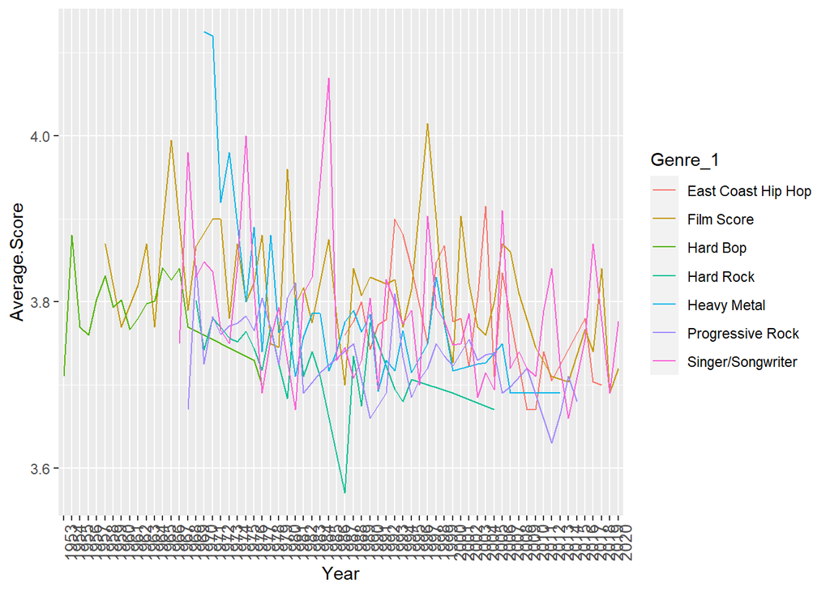

```r
df_final%>% filter(Genre_1 == "Progressive Rock"|
            Genre_1 == "Singer/Songwriter"|
            Genre_1 == "Hard Bop"|
            Genre_1 == "Film Score"|
            Genre_1 == "Hard Rock"|
            Genre_1 == "Heavy Metal"|
            Genre_1 == "East Coast Hip Hop"
            )%>% group_by(Genre_1 ,Year)%>% summarise(
              Average.Score = mean(Average.Rating),
              count = n()
              )%>% ggplot(aes(x = Year,y = Average.Score, group = Genre_1, color = Genre_1)) + geom_line()+ theme(axis.text.x = element_text(angle = 90, size = 10))
```

Most genre’s average scores over the years appear to be fairly consistent. Heavy Metal started out strong in 1970, but then suffered a steep decline by the end of the decade, plateauing around 3.75. Hard Rock had the lowest average score, and throughout the timeline barely broke 3.8 at its highest peak. Hard bop, Film Score, Singer/Songwriter and east coast hip hop seem to be oscillating around an average rating of 3.8.

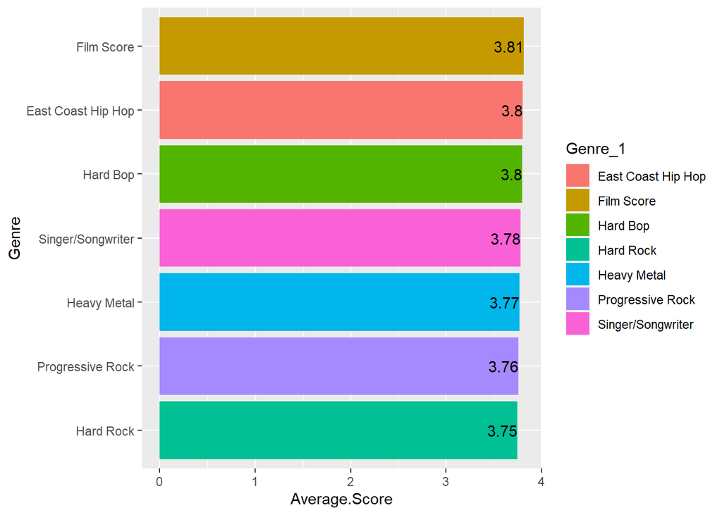

```r
df_final %>% group_by(Genre_1)%>%
  filter(
    Genre_1 == "Progressive Rock"|
    Genre_1 == "Singer/Songwriter"|
    Genre_1 == "Hard Bop"|
    Genre_1 == "Film Score"|
    Genre_1 == "Hard Rock"|
    Genre_1 == "Heavy Metal"|
    Genre_1 == "East Coast Hip Hop"
            )%>% summarise(
  Average.Score = mean(Average.Rating),
  count = n()
  ) %>% ggplot(aes(x=reorder(Genre_1,Average.Score),y=Average.Score, fill = Genre_1))+
  geom_bar(stat="identity")+
  coord_flip() +
  geom_text(aes(label=round(Average.Score, digit = 2), hjust = 1))+
  xlab("Genre")
```

The average scores for each genre are very similar which makes sense as we are looking at the top 5000 albums so they all should have fairly high scores. Film Score had the highest average score with 3.81, and Hard Rock had the lowest average score at 3.75.

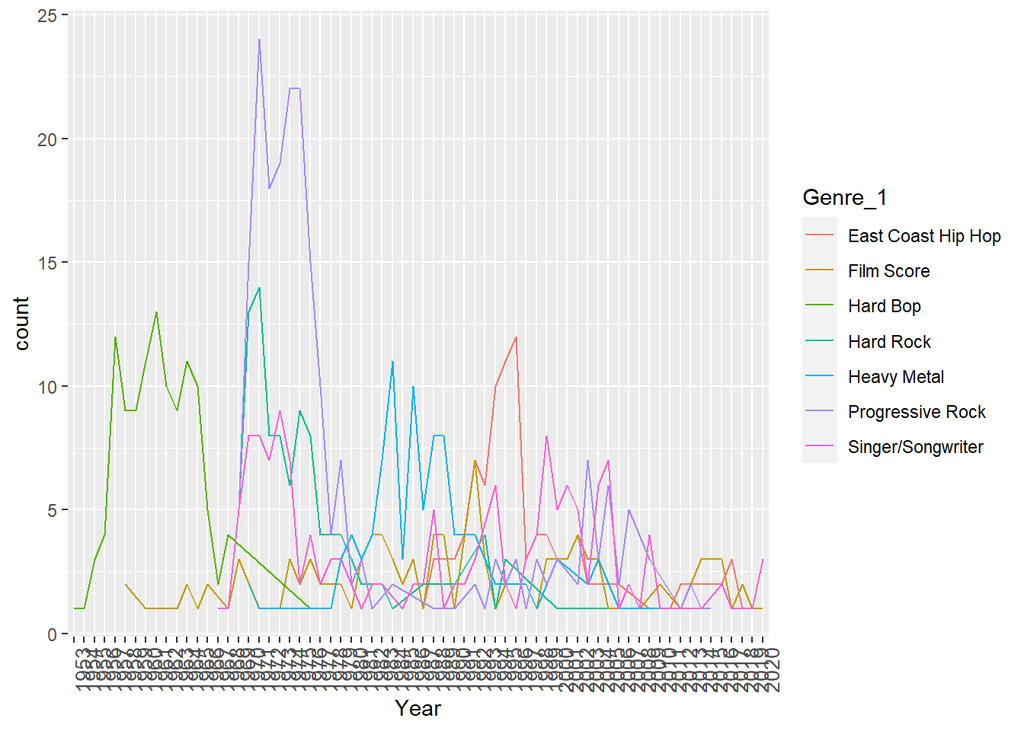

```r
df_final%>% filter(Genre_1 == "Progressive Rock"|
            Genre_1 == "Singer/Songwriter"|
            Genre_1 == "Hard Bop"|
            Genre_1 == "Film Score"|
            Genre_1 == "Hard Rock"|
            Genre_1 == "Heavy Metal"|
            Genre_1 == "East Coast Hip Hop"
            )%>% group_by(Genre_1 ,Year)%>% summarise(
  count = n()
)%>% ggplot(aes(x = Year,y = count, group = Genre_1, color = Genre_1)) + geom_line()+ theme(axis.text.x = element_text(angle = 90, size = 10))
```

To answer the question: How do Genre’s scores change over time? From the plot, the most popular genre’s scores appear to oscillate over the years, with a fairly consistent average around 3.8 for all genres.

________________________________________________________________________________________________________________

-What is the relationship between score and other variables, such as genre, descriptors, and artist? **Jasper**

By answering this question we will be able to have a better idea of how albums are scored and what the stronger criterion are that affect scores for each album. First we will look for the unique values of genres, descriptors and artists to identify how many of each category we have. Once that is accomplished, we will be using the dplyr library and grouping the data by genre to graph it with the ggplot library. Using these graphs we will be able to see how different categories affect score.

# First: Identify Question

# Question: What is the relationship between score and other variables, such as genre, descriptors, and artist?

### Find the Top 10 Most Common Genres, Descriptors, and Artists

```r
## Genre
df_final %>% group_by(Genre_1)%>% summarise(
  count = n()
)%>% arrange(desc(count))
```

```
## # A tibble: 453 × 2
##    Genre_1            count
##    <chr>              <int>
##  1 Progressive Rock     225
##  2 Singer/Songwriter    158
##  3 Hard Bop             116
##  4 Film Score           114
##  5 Hard Rock            111
##  6 Heavy Metal          108
##  7 East Coast Hip Hop   100
##  8 Video Game Music      96
##  9 Alternative Rock      93
## 10 Progressive Metal     80
## # … with 443 more rows
```

- Progressive Rock, Singer/Songwriter, Hard Bop, Film Score, Hard Rock, Heavy Metal, East Coast Hip Hop, Video Game Music, Alternative Rock, and Progressive Metal are the top 10 most common Genres.

```r
## Descriptor
df_final %>% group_by(Desc_1)%>% summarise(
  count = n()
)%>% arrange(desc(count))
```

```
## # A tibble: 166 × 2
##    Desc_1          count
##    <chr>           <int>
##  1 "male vocals"     411
##  2 "instrumental"    271
##  3 "energetic"       234
##  4 "melodic"         174
##  5 "melancholic"     171
##  6 "female vocals"   147
##  7 "atmospheric"     122
##  8 "psychedelic"     115
##  9 ""                114
## 10 "passionate"      114
## # … with 156 more rows
```

```r
## Artist
df_final %>% group_by(Artist.Name)%>% summarise(
  count = n()
)%>% arrange(desc(count))
```

```
## # A tibble: 2,787 × 2
##    Artist.Name     count
##    <chr>           <int>
##  1 Various Artists    25
##  2 Miles Davis        17
##  3 John Coltrane      14
##  4 Tom Waits          13
##  5 John Williams      12
##  6 Bob Dylan          11
##  7 The Beatles        10
##  8 Ennio Morricone     9
##  9 Herbie Hancock      9
## 10 Pharoah Sanders     9
## # … with 2,777 more rows
```

- Various Artists, Miles Davis, John Coltrane, Tom Waits, John Williams, Bob Dylan, The Beatles, Ennio Morricone, Herbie Hancock, Pharoah Sanders, and The Fall

### Average Score of the Top 10 Most Common Genres, Descriptors, and Artists

```r
## Mean of all albums in the list
mean(df_final$Average.Rating)
```

```
## [1] 3.771304
```

- The average score for all albums in the list is 3.771304.

```r
## Average score of Top 10 Genres
df_final_genres <- df_final[df_final$Genre_1==c("Progressive Rock", "Singer/Songwriter", "Hard Bop", "Film Score", "Hard Rock",
                                                "Heavy Metal", "East Coast Hip Hop", "Video Game Music", "Alternative Rock", "Progressive Metal"),]
mean(df_final_genres$Average.Rating)
```

```
## [1] 3.775546
```

- The average score for albums with their primary genre in the top 10 most common genre is 3.775546.

```r
## Average score of Top 10 Descriptors
df_final_descriptors <- df_final[df_final$Desc_1==c("male vocals", "instrumental", "energetic", "melodic", "melancholic",
                                                    "female vocals", "atmospheric", "psychedelic", "passionate", "dark"),]
mean(df_final_descriptors$Average.Rating)
```

```
## [1] 3.771124
```

- The average score for albums with their primary descriptor in the top 10 most common descriptors is 3.771124

```r
## Average score of Top 10 Artists
df_final_artists <- df_final[df_final$Artist.Name=="Various Artists" |  df_final$Artist.Name=="Miles Davis" | df_final$Artist.Name=="John Coltrane" |  df_final$Artist.Name=="Tom Waits" |
                            df_final$Artist.Name=="John Williams" | df_final$Artist.Name=="Bob Dylan" | df_final$Artist.Name=="The Beatles" |  df_final$Artist.Name=="Ennio Morricone" |
                            df_final$Artist.Name=="Herbie Hancock" | df_final$Artist.Name=="Pharoah Sanders" | df_final$Artist.Name=="The Fall",]
mean(df_final_artists$Average.Rating)
```

```
## [1] 3.855435
```

- The average score for albums with their artists in the top 10 most common artists is 3.855435.

```r
## Average Score of all Top 10's
df_final_top10s <- df_final[df_final$Genre_1==c("Progressive Rock", "Singer/Songwriter", "Hard Bop", "Film Score", "Hard Rock",
                                                "Heavy Metal", "East Coast Hip Hop", "Video Game Music", "Alternative Rock", "Progressive Metal") |
                            df_final$Desc_1==c("male vocals", "instrumental", "energetic", "melodic", "melancholic",
                                                    "female vocals", "atmospheric", "psychedelic", "passionate", "dark") |
                            df_final$Artist.Name=="Various Artists" |  df_final$Artist.Name=="Miles Davis" | df_final$Artist.Name=="John Coltrane" |  df_final$Artist.Name=="Tom Waits" |
                            df_final$Artist.Name=="John Williams" | df_final$Artist.Name=="Bob Dylan" | df_final$Artist.Name=="The Beatles" |  df_final$Artist.Name=="Ennio Morricone" |
                            df_final$Artist.Name=="Herbie Hancock" | df_final$Artist.Name=="Pharoah Sanders" | df_final$Artist.Name=="The Fall",]
mean(df_final_top10s$Average.Rating)
```

```
## [1] 3.797607
```

- The average score for an album with any of the previous top 10 values included in the album is 3.7976607.

### Average Score of !Top 10 most common genres, descriptors, artists

```r
## Average score without top 10 most common Genres
df_final_genres2 <- df_final[!df_final$Genre_1==c("Progressive Rock", "Singer/Songwriter", "Hard Bop", "Film Score", "Hard Rock",
                                                "Heavy Metal", "East Coast Hip Hop", "Video Game Music", "Alternative Rock", "Progressive Metal"),]
mean(df_final_genres2$Average.Rating)
```

```
## [1] 3.771201
```

- The average score when the top 10 most common primary genres are removed is 3.771201.

```r
## Average score without top 10 most common Descriptors
df_final_descriptors2 <- df_final[!df_final$Desc_1==c("male vocals", "instrumental", "energetic", "melodic", "melancholic",
                                                    "female vocals", "atmospheric", "psychedelic", "passionate", "dark"),]
mean(df_final_descriptors2$Average.Rating)
```

```
## [1] 3.771311
```

- The average score when the top 10 most common primary descriptors are removed is 3.771311

```r
## Average score without top 10 most common Artists
df_final_artists2 <- df_final[!df_final$Artist.Name=="Various Artists" &  !df_final$Artist.Name=="Miles Davis" & !df_final$Artist.Name=="John Coltrane" &
                             !df_final$Artist.Name=="Tom Waits" & !df_final$Artist.Name=="John Williams" & !df_final$Artist.Name=="Bob Dylan" &
                             !df_final$Artist.Name=="The Beatles" &  !df_final$Artist.Name=="Ennio Morricone" & !df_final$Artist.Name=="Herbie Hancock" &
                             !df_final$Artist.Name=="Pharoah Sanders" & !df_final$Artist.Name=="The Fall",]
mean(df_final_artists2$Average.Rating)
```

```
## [1] 3.768916
```

- The average score when the top 10 most common artists are removed is 3.768916.

```r
## Average score without all top 10's
df_final_top10s2 <- df_final[!df_final$Genre_1==c("Progressive Rock", "Singer/Songwriter", "Hard Bop", "Film Score", "Hard Rock",
                                                "Heavy Metal", "East Coast Hip Hop", "Video Game Music", "Alternative Rock", "Progressive Metal") &
                             !df_final$Desc_1==c("male vocals", "instrumental", "energetic", "melodic", "melancholic",
                                                    "female vocals", "atmospheric", "psychedelic", "passionate", "dark") &
                             !df_final$Artist.Name=="Various Artists" &  !df_final$Artist.Name=="Miles Davis" & !df_final$Artist.Name=="John Coltrane" &
                             !df_final$Artist.Name=="Tom Waits" & !df_final$Artist.Name=="John Williams" & !df_final$Artist.Name=="Bob Dylan" &
                             !df_final$Artist.Name=="The Beatles" &  !df_final$Artist.Name=="Ennio Morricone" & !df_final$Artist.Name=="Herbie Hancock" &
                             !df_final$Artist.Name=="Pharoah Sanders" & !df_final$Artist.Name=="The Fall",]
mean(df_final_top10s2$Average.Rating)
```

```
## [1] 3.768879
```

- The average score when the top 10 most common artists, genres, and descriptors are removed is 3.768879.

### Correlation matrix to find what is most correlated with score

```r
dummydf <- df_final

dummydf$Genre_1 <- as.numeric(factor(dummydf$Genre_1))
dummydf$Desc_1 <- as.numeric(factor(dummydf$Desc_1))
dummydf$Artist.Name <-  as.numeric(factor(dummydf$Artist.Name))
dummydf$Year <-  as.numeric(factor(dummydf$Year))
dummydf$Number.of.Ratings <-  as.numeric(factor(dummydf$Number.of.Ratings))
dummydf$Number.of.Reviews <-  as.numeric(factor(dummydf$Number.of.Reviews))

dummydf2 <- subset(dummydf, select=c("Average.Rating","Artist.Name", "Genre_1", "Desc_1", "Year", "Number.of.Ratings", "Number.of.Reviews"))
results <- cor(dummydf2)
round(results,2)
```

```
##                   Average.Rating Artist.Name Genre_1 Desc_1  Year
## Average.Rating              1.00        0.02    0.02   0.05 -0.17
## Artist.Name                 0.02        1.00    0.02   0.00  0.04
## Genre_1                     0.02        0.02    1.00   0.05 -0.03
## Desc_1                      0.05        0.00    0.05   1.00 -0.03
## Year                       -0.17        0.04   -0.03  -0.03  1.00
## Number.of.Ratings           0.35       -0.02   -0.03   0.05  0.17
## Number.of.Reviews           0.45        0.01   -0.01   0.05  0.01
##                   Number.of.Ratings Number.of.Reviews
## Average.Rating                 0.35              0.45
## Artist.Name                   -0.02              0.01
## Genre_1                       -0.03             -0.01
## Desc_1                         0.05              0.05
## Year                           0.17              0.01
## Number.of.Ratings              1.00              0.82
## Number.of.Reviews              0.82              1.00
```

- Using our correlation matrix we can see that Number.of.Reviews is our strongest predictor of Average Rating with Number.of.Ratings close behind. If we were making a model to predict the average rating for an album we would include the variables: Number.of.Reviews, Number.of.Ratings, and Year.